# Data Basics & Sampling Principles MTH 361 A/B Applied Statistics I Spring 2023

University of Portland

# R Packages

```r
library(tidyverse)
library(openintro)
```

R packages are groups of R functions, compiled code, and example data. In the R environment, they are saved in the `library` directory. R installs a set of packages by default after installation. More packages will be added later if they are required for a specific purpose. When we launch the R console, just the default packages are available. Other packages that are already installed must be explicitly loaded before they may be utilized by the R application.

# Loading Datasets

```r
county %>%
  slice(1:3) # selecting only 3 rows to display
```

```
## # A tibble: 3 × 15
##   name     state pop2000 pop2010 pop2017 pop_c…¹ poverty homeo…² multi…³ unemp…⁴
##   <chr>    <fct>   <dbl>   <dbl>   <int>   <dbl>   <dbl>   <dbl>   <dbl>   <dbl>
## 1 Autauga… Alab…   43671   54571   55504    1.48    13.7    77.5     7.2    3.86
## 2 Baldwin… Alab…  140415  182265  212628    9.19    11.8    76.7    22.6    3.99
## 3 Barbour… Alab…   29038   27457   25270   -6.22    27.2    68      11.1    5.9
## # … with 5 more variables: metro <fct>, median_edu <fct>,
## #   per_capita_income <dbl>, median_hh_income <int>, smoking_ban <fct>, and
## #   abbreviated variable names ¹pop_change, ²homeownership, ³multi_unit,
## #   ⁴unemployment_rate
```

The syntax `%>%` is a method to pipe results to another function. The `county` dataset is built in R dataset.

# Accessing Rows and Columns

- Using brackets to access **specific indices** of the data frame with the first 3 rows.

```r
county[1:3,1:5]
```

```
## # A tibble: 3 × 5
##   name           state   pop2000 pop2010 pop2017
##   <chr>          <fct>     <dbl>   <dbl>   <int>
## 1 Autauga County Alabama   43671   54571   55504
## 2 Baldwin County Alabama  140415  182265  212628
## 3 Barbour County Alabama   29038   27457   25270
```

- Using brackets to access **specific column labels** of the data frame with the first 3 rows.

```r
county[1:3,c("name","state","pop2000","pop2010")]
```

```
## # A tibble: 3 × 4
##   name           state   pop2000 pop2010
##   <chr>          <fct>     <dbl>   <dbl>
## 1 Autauga County Alabama   43671   54571
## 2 Baldwin County Alabama  140415  182265
## 3 Barbour County Alabama   29038   27457
```

# Accessing Entire Columns

- Using the `$` command to access a **specific column label** of the data.

```r
glimpse(county$pop2000)
```

```
##  num [1:3142] 43671 140415 29038 20826 51024 ...
```

- Using brackets to access **entire columns** using **specific column labels**.

```r
glimpse(county[,c("pop2000","pop2010","pop2017")])
```

```
## Rows: 3,142
## Columns: 3
## $ pop2000 <dbl> 43671, 140415, 29038, 20826, 51024, 11714, 21399, 112249, 3658…
## $ pop2010 <dbl> 54571, 182265, 27457, 22915, 57322, 10914, 20947, 118572, 3421…
## $ pop2017 <int> 55504, 212628, 25270, 22668, 58013, 10309, 19825, 114728, 3371…
```

# Basic Descriptive Statistics

- Using `$` command to **summarize one column**.

```r
summary(county$pop2000)
```

```
##    Min. 1st Qu.  Median    Mean 3rd Qu.    Max.    NA's
##      67   11224   24621   89650   61775 9519338       3
```

- Using brackets to **summarize multiple columns**.

```r
summary(county[,c("pop2000","pop2010","pop2017")])
```

```
##     pop2000           pop2010           pop2017
##  Min.   :     67   Min.   :     82   Min.   :      88
##  1st Qu.:  11224   1st Qu.:  11114   1st Qu.:   10976
##  Median :  24621   Median :  25872   Median :   25857
##  Mean   :  89650   Mean   :  98262   Mean   :  103763
##  3rd Qu.:  61775   3rd Qu.:  66780   3rd Qu.:   67756
##  Max.   :9519338   Max.   :9818605   Max.   :10163507
##  NA's   :3                           NA's   :3
```

- Computing **Mean and Standard Deviation of one column**.

```r
mean(county$pop2010)
```

```
## [1] 98262.04
```

```r
sd(county$pop2010)
```

```
## [1] 312946.7
```

# Histograms

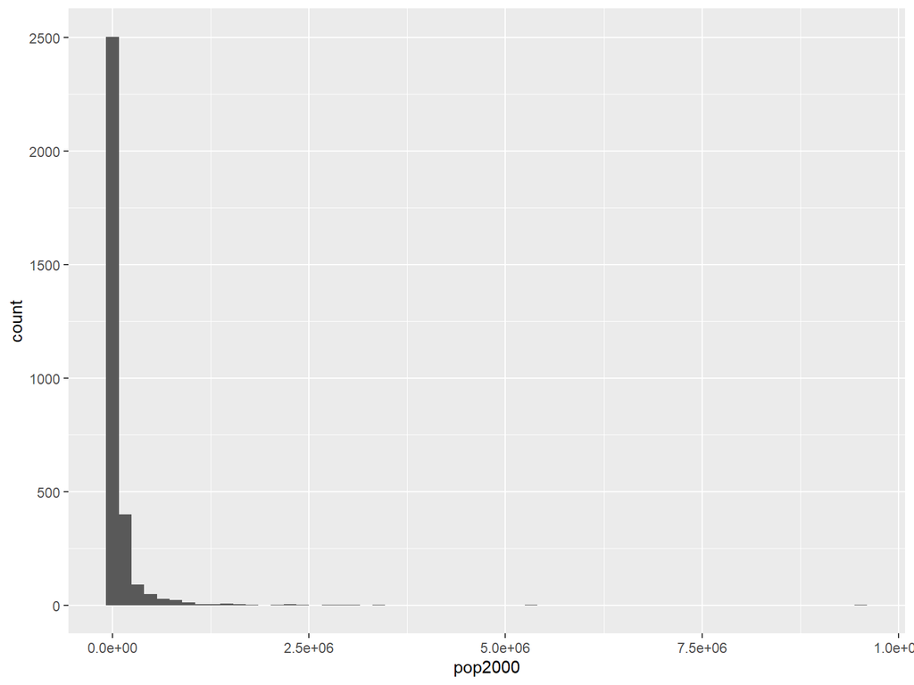

```r
ggplot(data = county, aes(x = pop2000)) + geom_histogram(bins=60)
```

# Scatterplots

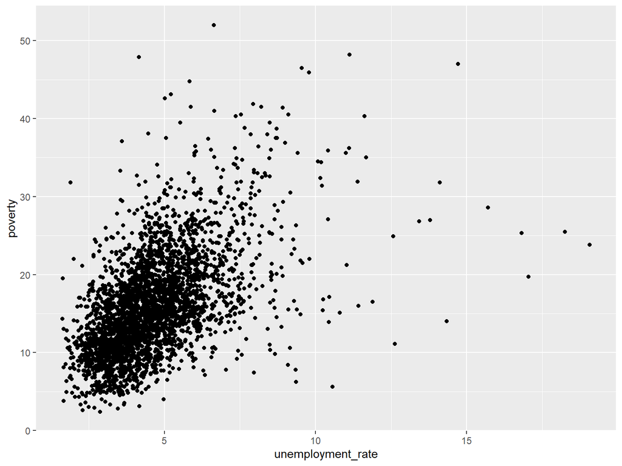

```r
ggplot(data = county, aes(x = unemployment_rate, y = poverty)) + geom_point()
```

# **Randomization and Sampling**

```r
county <- county %>% na.omit()
glimpse(county)
```

```
## Rows: 2,560
## Columns: 15
## $ name              <chr> "Autauga County", "Baldwin County", "Barbour County"…
## $ state             <fct> Alabama, Alabama, Alabama, Alabama, Alabama, Alabama…
## $ pop2000           <dbl> 43671, 140415, 29038, 20826, 51024, 11714, 36583, 23…
## $ pop2010           <dbl> 54571, 182265, 27457, 22915, 57322, 10914, 34215, 25…
## $ pop2017           <int> 55504, 212628, 25270, 22668, 58013, 10309, 33713, 25…
## $ pop_change        <dbl> 1.48, 9.19, -6.22, 0.73, 0.68, -2.28, -1.20, -0.60, …
## $ poverty           <dbl> 13.7, 11.8, 27.2, 15.2, 15.6, 28.5, 18.8, 16.1, 19.4…
## $ homeownership     <dbl> 77.5, 76.7, 68.0, 82.9, 82.0, 76.9, 71.4, 77.5, 75.1…
## $ multi_unit        <dbl> 7.2, 22.6, 11.1, 6.6, 3.7, 9.9, 8.7, 4.3, 4.4, 3.9, …
## $ unemployment_rate <dbl> 3.86, 3.99, 5.90, 4.39, 4.02, 4.93, 4.08, 4.05, 4.05…
## $ metro             <fct> yes, yes, no, yes, yes, no, no, no, yes, no, no, no,…
## $ median_edu        <fct> some_college, some_college, hs_diploma, hs_diploma, …
## $ per_capita_income <dbl> 27841.70, 27779.85, 17891.73, 20572.05, 21367.39, 15…
## $ median_hh_income  <int> 55317, 52562, 33368, 43404, 47412, 29655, 37342, 400…
## $ smoking_ban       <fct> none, none, partial, none, none, none, none, none, n…
```

# Simple Random Sampling

*Example:* Suppose we want to randomly sample 100 observations (rows) from the data frame.

```r
n <- 100 # number of samples
rand_index <- sample.int(dim(county)[1],n, replace = FALSE) # pick random row indices from the data frame
# the replace=FALSE means that we sampling without replacement
simple_random_sample <- county %>% slice(rand_index) # select rows using the random indices
glimpse(simple_random_sample)
```

```
## Rows: 100
## Columns: 15
## $ name              <chr> "Wilson County", "St. Helena Parish", "Franklin Coun…
## $ state             <fct> Texas, Louisiana, Florida, Tennessee, Texas, Oklahom…
## $ pop2000           <dbl> 32408, 10525, 11057, 569891, 43080, 10227, 5998, 959…
## $ pop2010           <dbl> 42918, 11203, 11549, 626681, 78337, 9446, 6499, 9208…
## $ pop2017           <int> 49304, 10363, 11727, 691243, 96788, 8893, 5938, 8795…
## $ pop_change        <dbl> 9.01, -3.79, 1.81, 4.75, 14.27, -4.76, 3.58, -2.16, …
## $ poverty           <dbl> 10.2, 26.4, 20.1, 16.9, 5.8, 23.9, 24.5, 16.4, 17.0,…
## $ homeownership     <dbl> 84.5, 78.8, 65.6, 57.6, 84.3, 66.4, 67.4, 82.6, 82.9…
## $ multi_unit        <dbl> 3.7, 2.3, 15.2, 37.2, 6.8, 7.4, 8.9, 3.7, 5.2, 4.3, …
## $ unemployment_rate <dbl> 3.46, 6.57, 3.58, 2.75, 3.31, 5.37, 2.70, 7.21, 4.08…
## $ metro             <fct> yes, yes, no, yes, yes, no, no, no, no, no, no, yes,…
## $ median_edu        <fct> hs_diploma, hs_diploma, hs_diploma, some_college, so…
## $ per_capita_income <dbl> 28941.89, 20496.92, 27243.91, 32091.67, 38227.36, 23…
## $ median_hh_income  <int> 71942, 35254, 41267, 53419, 93269, 38191, 32500, 409…
## $ smoking_ban       <fct> none, partial, partial, none, none, none, partial, n…
```

# Stratified Random Sampling

*Example 1:* Suppose we want to sample 50% of observations of each state in the data frame.

```r
strat_sample_frac <- county %>%
                     group_by(state) %>%# group by state (states as strata)
                     mutate(num_rows=n()) %>% # create new column that counts the number of observations in each strata
                     sample_frac(0.50, weight=num_rows) %>% # randomly sample 50% of observations in each strata
                     ungroup()
```

Now, let’s check if the code did it right.

```r
nto <- dim(county %>% filter(state == "California"))[1] # number of total observations
nso <- dim(strat_sample_frac %>% filter(state == "California"))[1] # number of sample observations

# this value should be close to 0.50
nso/nto
```

```
## [1] 0.5
```

*Example 2:* Suppose we want to sample exactly 100 observations in each level of the `metro` variable.

```r
stratified_sample <- county %>%
                     group_by(metro) %>%# group by metro (metro - yes or no - as strata)
                     sample_n(100) %>% # randomly sample 100 observations in each strata
                     ungroup

stratified_sample
```

```
## # A tibble: 200 × 15
##    name    state pop2000 pop2010 pop2017 pop_c…¹ poverty homeo…² multi…³ unemp…⁴
##    <chr>   <fct>   <dbl>   <dbl>   <int>   <dbl>   <dbl>   <dbl>   <dbl>   <dbl>
##  1 Lauren… Geor…   44874   48434   47330   -0.72    27.3    67.6    11.8    5.92
##  2 Cumber… Tenn…   46802   56053   59078    3.06    16      79.1     9.7    4.6
##  3 Lincol… Miss…   33166   34869   34347   -1.06    23.6    77.5     7.5    5.21
##  4 San Sa… Texas    6186    6131    5959    4.73    17.4    77.7     3.4    3.19
##  5 Rockbr… Virg…   20808   22307   22659    1.49    15.6    76.4     5      4.09
##  6 Bent C… Colo…    5998    6499    5938    3.58    24.5    67.4     8.9    2.7
##  7 Mussel… Mont…    4497    4538    4639   -0.56    17.4    76.7     5      4.44
##  8 Bath C… Virg…    5048    4731    4297   -6.34     9.3    87       0.9    3.3
##  9 Lamoil… Verm…   23233   24475   25337    1.11    14      69      19.7    3.96
## 10 Cullma… Alab…   77483   80406   82755    2.58    16.4    74.7     8.5    3.71
## # … with 190 more rows, 5 more variables: metro <fct>, median_edu <fct>,
## #   per_capita_income <dbl>, median_hh_income <int>, smoking_ban <fct>, and
## #   abbreviated variable names ¹pop_change, ²homeownership, ³multi_unit,
## #   ⁴unemployment_rate
```

# Clustered Random Sampling

*Example:* Suppose we consider each state as a cluster, and we randomly sample 10 clusters.

```r
n_clusters <- 10 # number of clusters to randomly sample
states <- levels(county$state) # get list of states
states_sample <- sample(states,n_clusters) # sample the states

county %>% filter(state==states_sample) # get the rows with corresponding states that are sampled.
```

```
## # A tibble: 36 × 15
##    name    state pop2000 pop2010 pop2017 pop_c…¹ poverty homeo…² multi…³ unemp…⁴
##    <chr>   <fct>   <dbl>   <dbl>   <int>   <dbl>   <dbl>   <dbl>   <dbl>   <dbl>
##  1 Dillin… Alas…    4922    4847    4932   -0.98    16.6    60.7    14.1    9.29
##  2 North … Alas…    7385    9430    9782    0.06    10.2    48.3    24.9    7.44
##  3 Alamed… Cali… 1443741 1510271 1663190    5.07    11.3    55.1    38      3.64
##  4 Glenn … Cali…   26453   28122   28094    0.82    19.6    67.5    11.4    7.46
##  5 Merced… Cali…  210554  255793  272673    3.79    23.3    55.9    17.3    9.3
##  6 Sacram… Cali… 1223499 1418788 1530615    4.87    16.7    59.5    26.9    4.64
##  7 Shasta… Cali…  163256  177223  179921    0.83    18.1    66      16      5.8
##  8 Tuolum… Cali…   54501   55365   54248    0.43    13.6    70.2     8.6    5.39
##  9 Archul… Colo…    9898   12084   13315    9.09    11.6    82.9    17      3
## 10 Custer… Colo…    3503    4255    4874   14.3     15.7    80.5     4.7    3.03
## # … with 26 more rows, 5 more variables: metro <fct>, median_edu <fct>,
## #   per_capita_income <dbl>, median_hh_income <int>, smoking_ban <fct>, and
## #   abbreviated variable names ¹pop_change, ²homeownership, ³multi_unit,
## #   ⁴unemployment_rate
```